# What Makes Good Wine?

# 1 Introduction

In this paper, we examine a dataset containing information about different kinds of wines to understand the relationship between the chemical makeup, type, and quality of wine. We seek to answer two SMART questions:

1. Can we classify the type of wine (red or white) given its chemical makeup?
2. Can we predict the quality of a certain type of wine (white or red) given its chemical makeup?

First, we include some exploratory data analysis (EDA) to better understand our data. To answer our SMART questions, we then conduct a variety of analyses, including K-means, Principal Component Analysis and Regression, Logistic Regression, KNN, Decision Trees, and Random Forests. We repeat all of these analyses three times: once to answer SMART question #1, once to answer SMART question #2 for red wine, and once to answer SMART question #2 for white wine. We then compare the accuracy of these analyses to understand which one results in the most accurate classification.

## 1.1 The Data

The variables in the original data are: type, fixed acidity, volatile acidity, citric acid, residual sugar, chlorides, free sulfur dioxide, total sulfur dioxide, density, pH, sulphates, alcohol, and quality (on a scale from 1-10).  
Below is the structure of the dataset and the statistical summary of the numerical variables:

```
## 'data.frame':    6463 obs. of  13 variables:
##  $ type                : Factor w/ 2 levels "red","white": 2 2 2 2 2 2 2 2 2 2 ...
##  $ fixed.acidity       : num  7 6.3 8.1 7.2 7.2 8.1 6.2 7 6.3 8.1 ...
##  $ volatile.acidity    : num  0.27 0.3 0.28 0.23 0.23 0.28 0.32 0.27 0.3 0.22 ...
##  $ citric.acid         : num  0.36 0.34 0.4 0.32 0.32 0.4 0.16 0.36 0.34 0.43 ...
##  $ residual.sugar      : num  20.7 1.6 6.9 8.5 8.5 6.9 7 20.7 1.6 1.5 ...
##  $ chlorides           : num  0.045 0.049 0.05 0.058 0.058 0.05 0.045 0.045 0.049 0.044 ...
##  $ free.sulfur.dioxide : num  45 14 30 47 47 30 30 45 14 28 ...
##  $ total.sulfur.dioxide: num  170 132 97 186 186 97 136 170 132 129 ...
##  $ density             : num  1.001 0.994 0.995 0.996 0.996 ...
##  $ pH                  : num  3 3.3 3.26 3.19 3.19 3.26 3.18 3 3.3 3.22 ...
##  $ sulphates           : num  0.45 0.49 0.44 0.4 0.4 0.44 0.47 0.45 0.49 0.45 ...
##  $ alcohol             : num  8.8 9.5 10.1 9.9 9.9 10.1 9.6 8.8 9.5 11 ...
##  $ quality             : int  6 6 6 6 6 6 6 6 6 6 ...
```

Table: Statistics summary.

|  | fixed.acidity | volatile.acidity | citric.acid | residual.sugar | chlorides | free.sulfur.dioxide | total.sulfur.dioxide | density | pH | sulphates | alcohol |
| --- | --- | --- | --- | --- | --- | --- | --- | --- | --- | --- | --- |
| Min | 3.80 | 0.08 | 0.000 | 0.6 | 0.009 | 1.0 | 6 | 0.987 | 2.72 | 0.220 | 8.0 |
| Q1 | 6.40 | 0.23 | 0.250 | 1.8 | 0.038 | 17.0 | 77 | 0.992 | 3.11 | 0.430 | 9.5 |
| Median | 7.00 | 0.29 | 0.310 | 3.0 | 0.047 | 29.0 | 118 | 0.995 | 3.21 | 0.510 | 10.3 |
| Mean | 7.22 | 0.34 | 0.319 | 5.4 | 0.056 | 30.5 | 116 | 0.995 | 3.22 | 0.531 | 10.5 |
| Q3 | 7.70 | 0.40 | 0.390 | 8.1 | 0.065 | 41.0 | 156 | 0.997 | 3.32 | 0.600 | 11.3 |
| Max | 15.90 | 1.58 | 1.660 | 65.8 | 0.611 | 289.0 | 440 | 1.039 | 4.01 | 2.000 | 14.9 |

Below is how the quality rating of wine varies with alcohol content:

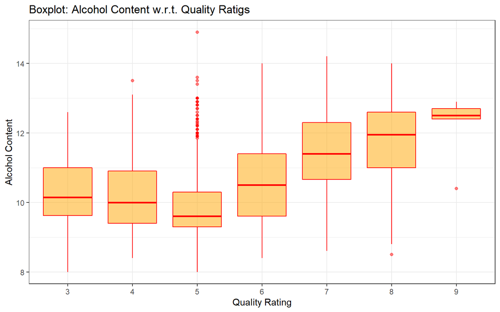

Below is how the Good Vs Bad of wines differ with alcohol content:

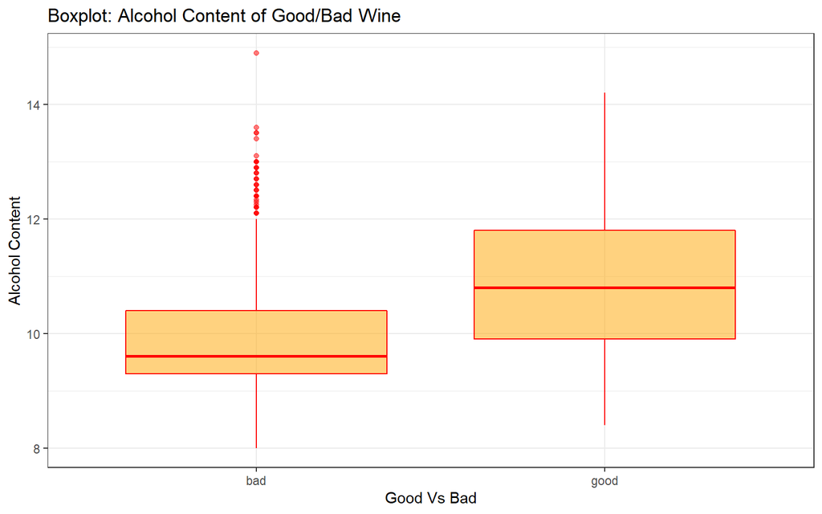

# 2 Classifying Wine Type

## 2.1 K-Means

Before building the actual models, it’s important to detect potential patterns in the data using K-Means clustering.

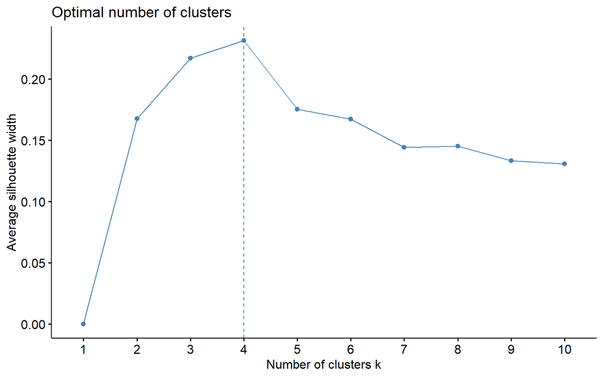

Here we see that this data works best in four clusters.

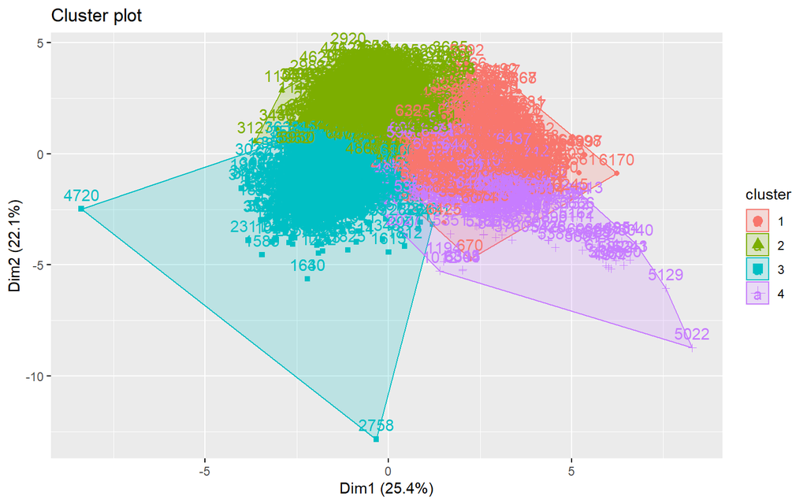

From this we see Dimension 1 seperates clusters 1 & 4 from clusters 2 & 3. Dimension 2 seperates clusters 1 & 2 from clusters 3 & 4. There is a lot of overlap in the center however there is in fact a clear patten occuring here.

## 2.2 PCA

First, we subset the data to only include the numeric variables. This excludes wine type (red/white) as well as quality, which is a binary variable in our case.

After scaling the data, we created principal components out of the variables and looked at the distribution of each one:

```
## Importance of components:
##                          PC1   PC2   PC3    PC4    PC5    PC6    PC7
## Standard deviation     1.741 1.580 1.247 0.9854 0.8486 0.7786 0.7233
## Proportion of Variance 0.276 0.227 0.141 0.0883 0.0655 0.0551 0.0476
## Cumulative Proportion  0.276 0.502 0.644 0.7320 0.7974 0.8526 0.9001
##                           PC8    PC9   PC10    PC11
## Standard deviation     0.7082 0.5805 0.4769 0.18101
## Proportion of Variance 0.0456 0.0306 0.0207 0.00298
## Cumulative Proportion  0.9457 0.9764 0.9970 1.00000
```

We also looked at how the variables make up each component:

```
##                          PC1     PC2     PC3     PC4    PC5     PC6
## fixed.acidity         0.2425 -0.3339  0.4328 -0.1654  0.146  0.2055
## volatile.acidity      0.3814 -0.1148 -0.3084 -0.2125 -0.153  0.4886
## citric.acid          -0.1498 -0.1847  0.5918  0.2642  0.157 -0.2288
## residual.sugar       -0.3441 -0.3325 -0.1637 -0.1657  0.352  0.2364
## chlorides             0.2922 -0.3129 -0.0172  0.2432 -0.613 -0.1672
## free.sulfur.dioxide  -0.4308 -0.0757 -0.1328  0.3554 -0.227  0.3374
## total.sulfur.dioxide -0.4869 -0.0912 -0.1062  0.2078 -0.160  0.1501
## density               0.0491 -0.5836 -0.1751 -0.0716  0.307 -0.0162
## pH                    0.2164  0.1568 -0.4552  0.4194  0.456 -0.2931
## sulphates             0.2951 -0.1899  0.0725  0.6396  0.129  0.3021
## alcohol               0.1027  0.4663  0.2613  0.1071  0.184  0.5187
##                          PC7      PC8    PC9     PC10      PC11
## fixed.acidity         0.2955 -0.39309 -0.344  0.28115  0.334913
## volatile.acidity      0.3879  0.10000  0.498 -0.15287  0.084822
## citric.acid           0.3712  0.30202  0.403 -0.23476 -0.000703
## residual.sugar       -0.2315  0.51934 -0.109  0.00111  0.449377
## chlorides             0.0355  0.47259 -0.298  0.19551  0.043066
## free.sulfur.dioxide   0.3063 -0.20060 -0.365 -0.48149 -0.000719
## total.sulfur.dioxide  0.1440 -0.12372  0.321  0.71355 -0.062443
## density               0.0460 -0.00408 -0.113  0.00426 -0.715333
## pH                    0.4145  0.03794 -0.127  0.14018  0.206250
## sulphates            -0.5213 -0.17937  0.207 -0.04497  0.076755
## alcohol               0.0966  0.40253 -0.252  0.20387 -0.335875
```

Using biplots is another way to see how the different variables make up each component. Here are a few examples:

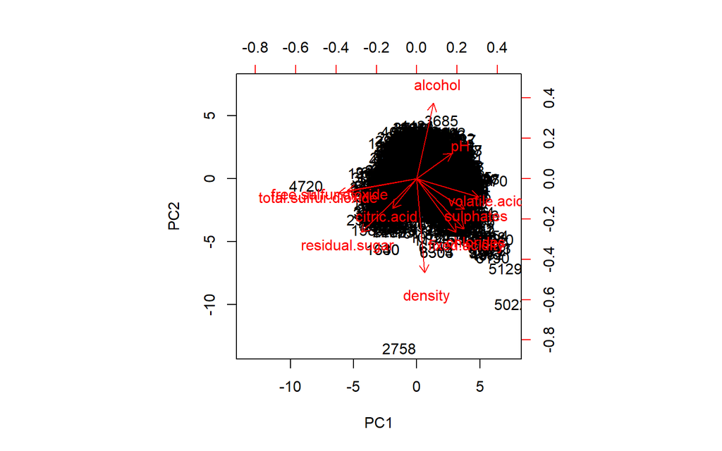

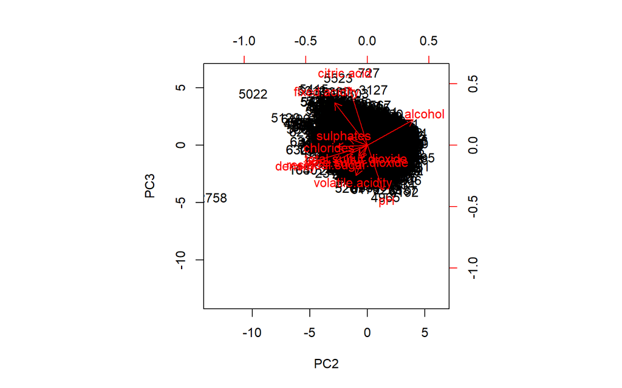

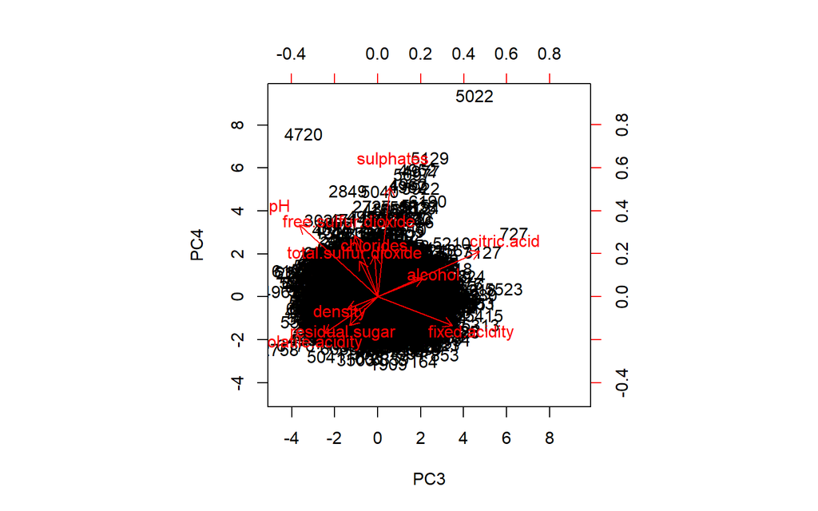

We can also plot the cumulative proportion of variance explained by the principal components:

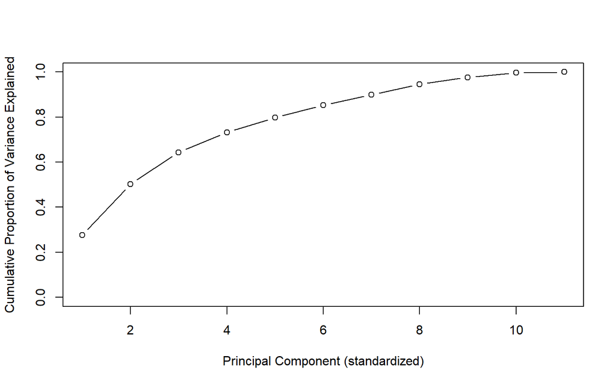

With 8 principal components, about 95% of the variance is explained. After this, the curve starts to level off, so including these first 8 components in a model is sufficient.

## 2.3 PCR

Finally, we created a PCR model with these 8 components. The model predicts whether the wine is white or red - a binary variable - so it uses logistic regression.

Table

|  | Estimate | Std. Error | z value | Pr(>\|z\|) |
| --- | --- | --- | --- | --- |
| (Intercept) | 4.5648 | 0.2170 | 21.035 | 0.0000 |
| PC1 | -3.9177 | 0.1706 | -22.958 | 0.0000 |
| PC2 | 0.8885 | 0.0786 | 11.308 | 0.0000 |
| PC3 | 0.1186 | 0.0836 | 1.418 | 0.1563 |
| PC4 | -0.4378 | 0.1043 | -4.197 | 0.0000 |
| PC5 | -0.3415 | 0.1002 | -3.409 | 0.0007 |
| PC6 | -0.0358 | 0.1224 | -0.292 | 0.7700 |
| PC7 | -0.8219 | 0.1653 | -4.971 | 0.0000 |
| PC8 | 0.5312 | 0.1300 | 4.086 | 0.0000 |

## 2.4 Logistic Regression

We then created a full logistic regression model, using the same variables from the original data (again excluding wine quality, since it is a categorical variable and is therefore not included in our PCR):

Table

|  | Estimate | Std. Error | z value | Pr(>\|z\|) |
| --- | --- | --- | --- | --- |
| (Intercept) | 1.84e+03 | 185.7263 | 9.90 | 0.000 |
| fixed.acidity | 3.83e-01 | 0.2345 | 1.63 | 0.103 |
| volatile.acidity | -6.24e+00 | 1.0246 | -6.09 | 0.000 |
| citric.acid | 2.58e+00 | 1.1726 | 2.20 | 0.028 |
| residual.sugar | 9.44e-01 | 0.1007 | 9.37 | 0.000 |
| chlorides | -2.22e+01 | 3.9827 | -5.58 | 0.000 |
| free.sulfur.dioxide | -6.69e-02 | 0.0133 | -5.03 | 0.000 |
| total.sulfur.dioxide | 5.32e-02 | 0.0049 | 10.87 | 0.000 |
| density | -1.84e+03 | 189.4308 | -9.70 | 0.000 |
| pH | 1.70e+00 | 1.4148 | 1.20 | 0.230 |
| sulphates | -3.09e+00 | 1.2426 | -2.48 | 0.013 |
| alcohol | -1.90e+00 | 0.2773 | -6.84 | 0.000 |

The results of this logistic model reveal some interesting relationships between chemical composition and wine type. It appears red and white wine are clearly distinguishable along these characteristics, since we see statistically signigifcant coefficients for most of the variables with the exception of fixed acidity and pH. The positive coefficients indicate features which increase the log likelihood of the wine being ‘white’; an increase in citric acid, residual sugar and total sulfur dioxide levels all increase the likelihood of white classification. On the other hand, the negative coefficients on volatile acidity, chlorides, free sulfur dioxide, density, suplphates and alcohol levels all point towards a higher log likelihood of the wine not being white, in which case it is classified as red.

This allowed us to compare the PCR model with the full logistic regression model by using different model evaluation techniques. For example, based on the regression results, the AIC for the full model is lower than for the PCR model (452.6 vs. 681), indicating a better fit. In addition, using the confusion matrices below, we calculated the accuracy of each model:

```
##              Predicted red Predicted white Total
## Actual red            1551              42  1593
## Actual white            39            4831  4870
## Total                 1590            4873  6463
```

```
##              Predicted red Predicted white Total
## Actual red            1575              18  1593
## Actual white            15            4855  4870
## Total                 1590            4873  6463
```

The accuracy of the PCR model is 0.987, while the accuracy of the full logistic regression model is slightly higher, at 0.995. This reinforces our finding that the full model is a better fit.

We now look at some other model evaluation metrics for the full logistic regression model.

**Model Evaluation for Logistic Regression**

```
## Area under the curve: 0.996
```

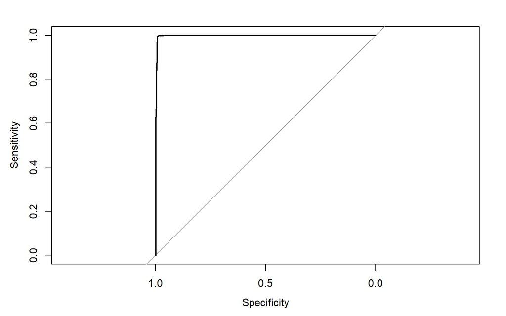

We look at the Area Under Curve (AOC) for this model, which measures the sensitivity against the specificity. The AOC comes out to be very high at 99.6%. Therefore this logistic regression model is a good fit for classiying wine type. Next, we look at the McFadden value for this regression.

```
## 'log Lik.' 0.941 (df=12)
```

The McFadden value for this test is also very high at 0.941. So about 94.1% of the variation in wine type is explained by the checmical composition explanatory variables. Once again, this reaffirms the fact that this logistic regression model is a good fit.

## 2.5 KNN

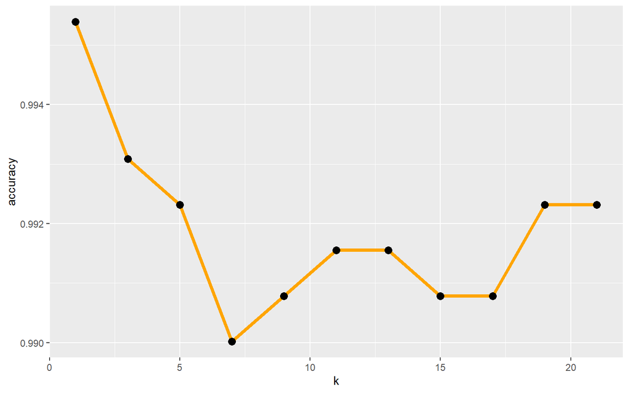

From this plot we could see the highest point of K value is at 1 and then it goest down. However, K value cannot not be 1 at the same time we avoild the value of K=2. Therefore, K=3 could give us the highest accuracy of the whole dataset.

```
##
##
##    Cell Contents
## |-------------------------|
## |                       N |
## |           N / Row Total |
## |           N / Col Total |
## |         N / Table Total |
## |-------------------------|
##
##
## Total Observations in Table:  1302
##
##
##                 | wine_pred
## wine.testLabels |       red |     white | Row Total |
## ----------------|-----------|-----------|-----------|
##             red |       310 |         4 |       314 |
##                 |     0.987 |     0.013 |     0.241 |
##                 |     0.984 |     0.004 |           |
##                 |     0.238 |     0.003 |           |
## ----------------|-----------|-----------|-----------|
##           white |         5 |       983 |       988 |
##                 |     0.005 |     0.995 |     0.759 |
##                 |     0.016 |     0.996 |           |
##                 |     0.004 |     0.755 |           |
## ----------------|-----------|-----------|-----------|
##    Column Total |       315 |       987 |      1302 |
##                 |     0.242 |     0.758 |           |
## ----------------|-----------|-----------|-----------|
##
##
```

```
## Confusion Matrix and Statistics
##
##                wine_pred
## wine.testLabels red white
##           red   310     4
##           white   5   983
##
##                Accuracy : 0.993
##                  95% CI : (0.987, 0.997)
##     No Information Rate : 0.758
##     P-Value [Acc > NIR] : <2e-16
##
##                   Kappa : 0.981
##
##  Mcnemar's Test P-Value : 1
##
##             Sensitivity : 0.984
##             Specificity : 0.996
##          Pos Pred Value : 0.987
##          Neg Pred Value : 0.995
##              Prevalence : 0.242
##          Detection Rate : 0.238
##    Detection Prevalence : 0.241
##       Balanced Accuracy : 0.990
##
##        'Positive' Class : red
##
```

We now run a crosstable with the value of K=3 to see the accuracy. From the crosstable we could see that the columns are the predicted values based on KNN while the rows are the actual values. There are 310 of those that are correctly predicted as red, 983 are correctly predicted as white wines. Since the accuracy is calculated by doing true positive + true negative)/total; therefore, the accuracy of KNN model in the whole wine group is 99.3%.

## 2.6 Decision Trees

[figure not shown]

Above is a sample decision tree, where in we can observe the sequence of importance of features while determining the Wine TYpe such as total.sulfur.dioxide, chlorides and so on.

**Pruning the trees**

Classification Trees summary with varying MaxDepth

| Depth | Accuracy | Sensitivity | Specificity | Pos.Pred.Value | Neg.Pred.Value | Precision | Recall | F1 | Prevalence | Detection.Rate | Detection.Prevalence | Balanced.Accuracy |
| --- | --- | --- | --- | --- | --- | --- | --- | --- | --- | --- | --- | --- |
| 2 | 0.955 | 0.960 | 0.954 | 0.873 | 0.986 | 0.873 | 0.960 | 0.914 | 0.248 | 0.238 | 0.273 | 0.957 |
| 3 | 0.975 | 0.938 | 0.987 | 0.960 | 0.980 | 0.960 | 0.938 | 0.949 | 0.248 | 0.233 | 0.242 | 0.963 |
| 4 | 0.983 | 0.954 | 0.992 | 0.975 | 0.985 | 0.975 | 0.954 | 0.964 | 0.248 | 0.236 | 0.242 | 0.973 |
| 5 | 0.983 | 0.954 | 0.992 | 0.975 | 0.985 | 0.975 | 0.954 | 0.964 | 0.248 | 0.236 | 0.242 | 0.973 |
| 6 | 0.983 | 0.954 | 0.992 | 0.975 | 0.985 | 0.975 | 0.954 | 0.964 | 0.248 | 0.236 | 0.242 | 0.973 |

We can oberve that accuracy saturates once the max depth reached 4. Hence, we can set max-depth = 4 for better performance.

```
##
##
##    Cell Contents
## |-------------------------|
## |                       N |
## |           N / Row Total |
## |           N / Col Total |
## |         N / Table Total |
## |-------------------------|
##
##
## Total Observations in Table:  1302
##
##
##                           | predDT
## wine_data_step1_test$type |       red |     white | Row Total |
## --------------------------|-----------|-----------|-----------|
##                       red |       297 |        17 |       314 |
##                           |     0.946 |     0.054 |     0.241 |
##                           |     0.964 |     0.017 |           |
##                           |     0.228 |     0.013 |           |
## --------------------------|-----------|-----------|-----------|
##                     white |        11 |       977 |       988 |
##                           |     0.011 |     0.989 |     0.759 |
##                           |     0.036 |     0.983 |           |
##                           |     0.008 |     0.750 |           |
## --------------------------|-----------|-----------|-----------|
##              Column Total |       308 |       994 |      1302 |
##                           |     0.237 |     0.763 |           |
## --------------------------|-----------|-----------|-----------|
##
##
```

Decision Trees Results

| Accuracy | Sensitivity | Specificity | Pos.Pred.Value | Neg.Pred.Value | Precision | Recall | F1 | Prevalence | Detection.Rate | Detection.Prevalence | Balanced.Accuracy |
| --- | --- | --- | --- | --- | --- | --- | --- | --- | --- | --- | --- |
| 0.979 | 0.946 | 0.989 | 0.964 | 0.983 | 0.964 | 0.946 | 0.955 | 0.241 | 0.228 | 0.237 | 0.967 |

Decision trees are able to classify the wine into Red and White with an accuracy of **0.978**.

## 2.7 Random Forest

**Tuning the Trees Count**

Random Forest summary with varying Trees Count

| Trees_Count | Accuracy | Sensitivity | Specificity | Pos.Pred.Value | Neg.Pred.Value | Precision | Recall | F1 | Prevalence | Detection.Rate | Detection.Prevalence | Balanced.Accuracy |
| --- | --- | --- | --- | --- | --- | --- | --- | --- | --- | --- | --- | --- |
| 250 | 0.995 | 0.984 | 0.999 | 0.996 | 0.995 | 0.996 | 0.984 | 0.990 | 0.248 | 0.244 | 0.245 | 0.992 |
| 300 | 0.995 | 0.983 | 0.999 | 0.995 | 0.994 | 0.995 | 0.983 | 0.989 | 0.248 | 0.244 | 0.245 | 0.991 |
| 350 | 0.995 | 0.982 | 0.999 | 0.996 | 0.994 | 0.996 | 0.982 | 0.989 | 0.248 | 0.243 | 0.244 | 0.990 |
| 400 | 0.995 | 0.984 | 0.999 | 0.995 | 0.995 | 0.995 | 0.984 | 0.989 | 0.248 | 0.244 | 0.245 | 0.991 |
| 450 | 0.995 | 0.983 | 0.999 | 0.996 | 0.994 | 0.996 | 0.983 | 0.989 | 0.248 | 0.244 | 0.244 | 0.991 |
| 500 | 0.994 | 0.981 | 0.999 | 0.996 | 0.994 | 0.996 | 0.981 | 0.989 | 0.248 | 0.243 | 0.244 | 0.990 |
| 550 | 0.995 | 0.983 | 0.999 | 0.995 | 0.994 | 0.995 | 0.983 | 0.989 | 0.248 | 0.244 | 0.245 | 0.991 |
| 600 | 0.995 | 0.982 | 0.999 | 0.996 | 0.994 | 0.996 | 0.982 | 0.989 | 0.248 | 0.243 | 0.244 | 0.990 |

With trees count =250 we seem to be getting the optimised mix of performance parameters.

```
##
##
##    Cell Contents
## |-------------------------|
## |                       N |
## |           N / Row Total |
## |           N / Col Total |
## |         N / Table Total |
## |-------------------------|
##
##
## Total Observations in Table:  1302
##
##
##                           | predRF
## wine_data_step1_test$type |       red |     white | Row Total |
## --------------------------|-----------|-----------|-----------|
##                       red |       310 |         4 |       314 |
##                           |     0.987 |     0.013 |     0.241 |
##                           |     0.990 |     0.004 |           |
##                           |     0.238 |     0.003 |           |
## --------------------------|-----------|-----------|-----------|
##                     white |         3 |       985 |       988 |
##                           |     0.003 |     0.997 |     0.759 |
##                           |     0.010 |     0.996 |           |
##                           |     0.002 |     0.757 |           |
## --------------------------|-----------|-----------|-----------|
##              Column Total |       313 |       989 |      1302 |
##                           |     0.240 |     0.760 |           |
## --------------------------|-----------|-----------|-----------|
##
##
```

Random Forest Results

| Accuracy | Sensitivity | Specificity | Pos.Pred.Value | Neg.Pred.Value | Precision | Recall | F1 | Prevalence | Detection.Rate | Detection.Prevalence | Balanced.Accuracy |
| --- | --- | --- | --- | --- | --- | --- | --- | --- | --- | --- | --- |
| 0.995 | 0.987 | 0.997 | 0.99 | 0.996 | 0.99 | 0.987 | 0.989 | 0.241 | 0.238 | 0.24 | 0.992 |

Random Forest is able to classify the wine into Red and White with an accuracy of **0.995**.

## 2.8 Conclusion

Wine Type Classification: All Model Comparison

| Model | Accuracy |
| --- | --- |
| PCR | 0.988 |
| Logistic Regression | 0.995 |
| KNN | 0.993 |
| Decision Trees | 0.979 |
| Random Forest | 0.995 |

We can observe high accuarcy rate from all the models, and **Random Forest** seems to be the best classifier of wine in terms of Red and White.

## 2.9 Accuracy, Too good to be true!

As per the above comparison table, we notice that every model is acheiving an accuracy somewhere close to 99%, which also makes us to ponder that may be both wine types vary significantly in terms of the predictor variables available to us. We performed two sample t test one by one for all of them to see if they actually are very different.

Wine Type Classification: How Different are both wines?

| Variable | Red Wine Mean | White Wine Mean | P-Value |
| --- | --- | --- | --- |
| fixed.acidity | 8.4825 | 6.8020 | 0.00 |
| volatile.acidity | 0.4738 | 0.2619 | 0.00 |
| citric.acid | 0.3007 | 0.3340 | 0.00 |
| residual.sugar | 2.5373 | 6.0696 | 0.00 |
| chlorides | 0.0827 | 0.0429 | 0.00 |
| free.sulfur.dioxide | 15.2021 | 35.2966 | 0.00 |
| total.sulfur.dioxide | 39.2714 | 133.1920 | 0.00 |
| density | 0.9965 | 0.9935 | 0.00 |
| pH | 3.3102 | 3.1969 | 0.00 |
| sulphates | 0.6923 | 0.4940 | 0.00 |
| alcohol | 10.8512 | 10.8517 | 0.99 |

We can clearly see that apart from alcohol content, both wine types are different in terms of other variables (p-value <0.05). This validates the reason why the classification models are so accurate.

# 3 Classifying Good and Bad Wine Given Type

We now break our data into two dataframes, isolating data to each wine type, red and white.

## 3.1 Defining Good Vs Bad

Lets plot and see how both wines quality is distributed individually.

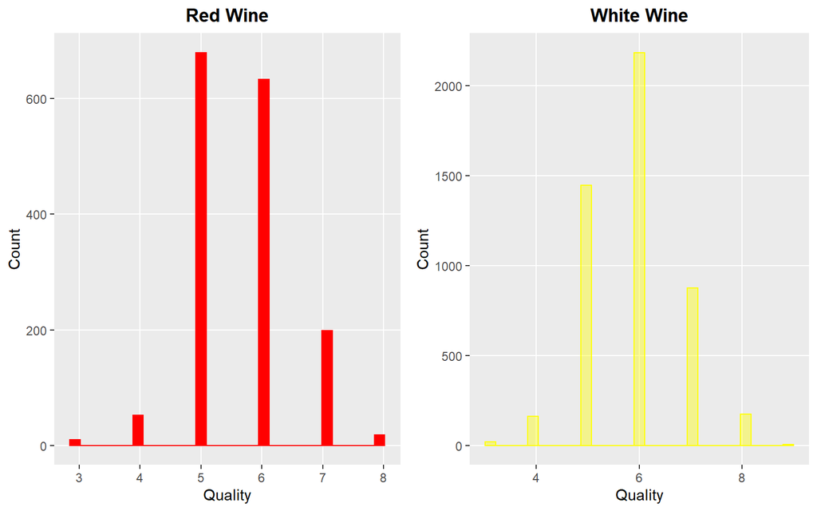

To ensure that data is balanced for both the classes i.e., Good and Bad, we have kept Quality Rating = 5 as the threshold, which means wines with Quality > 5 are Good, while the rest are Bad.

## 3.2 K-Means

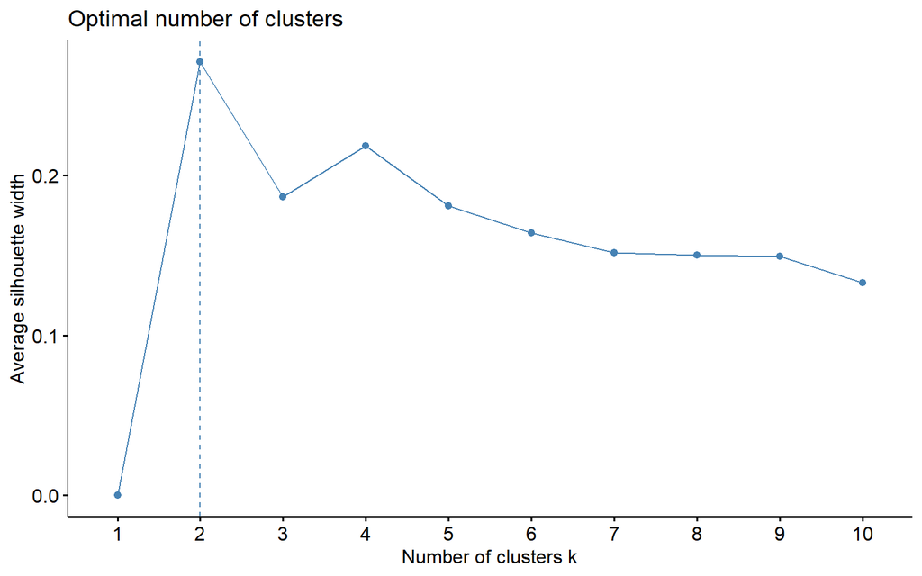

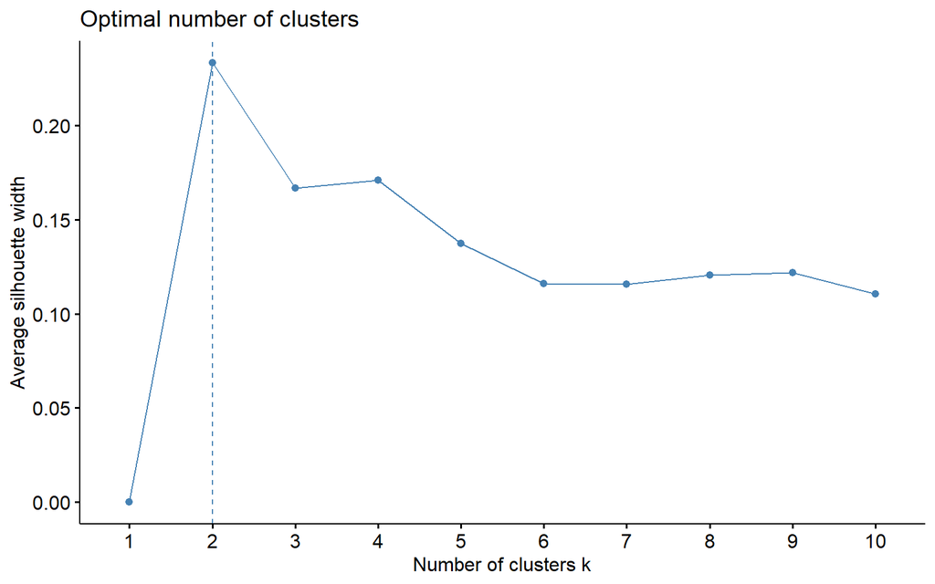

Here we see two clusters are best for both wine groups.

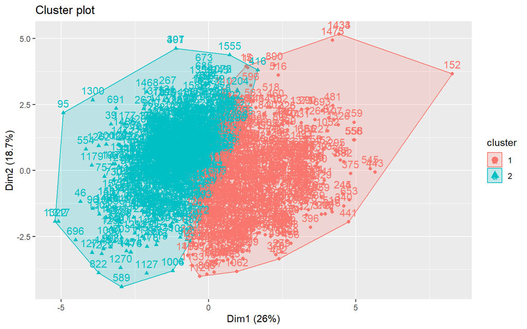

In classifying good red wine, we see Dimension 1 tells us alot about the differences in clusters, indicating a strong pattern in the data. Dimension 2 does to an extent but nothing to crazy.

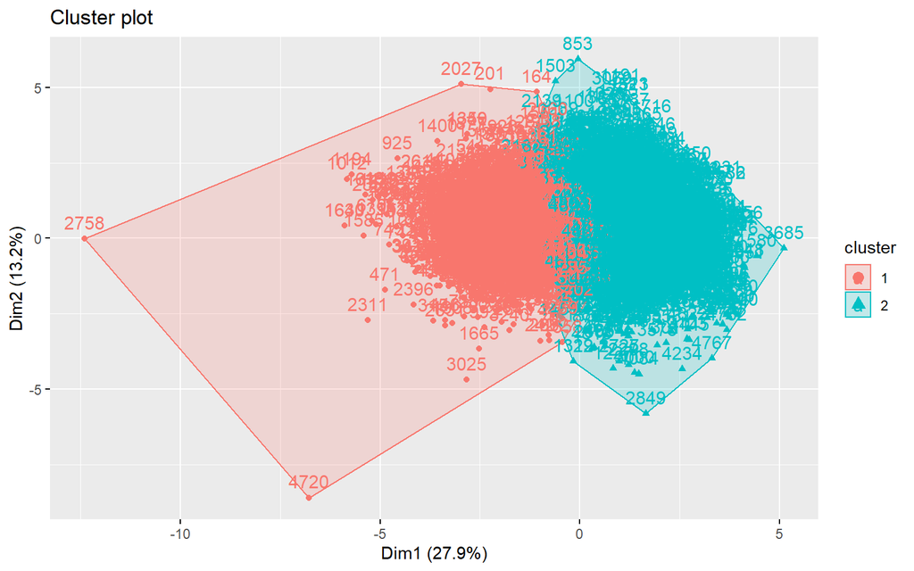

## 3.3 PCA

### 3.3.1 Red Wine PCA

First, we subsetted the data to include only red wine. Then we eliminated all non-numeric variables because we can’t use them for PCA.

After scaling the data, we created principal components out of the variables and looked at the distribution of each one:

```
## Importance of components:
##                          PC1   PC2   PC3   PC4    PC5    PC6    PC7    PC8
## Standard deviation     1.760 1.390 1.244 1.102 0.9790 0.8118 0.7631 0.6511
## Proportion of Variance 0.282 0.176 0.141 0.110 0.0871 0.0599 0.0529 0.0385
## Cumulative Proportion  0.282 0.457 0.598 0.708 0.7954 0.8553 0.9083 0.9468
##                           PC9   PC10    PC11
## Standard deviation     0.5867 0.4260 0.24409
## Proportion of Variance 0.0313 0.0165 0.00542
## Cumulative Proportion  0.9781 0.9946 1.00000
```

We also looked at how the variables make up each component:

```
##                         PC1      PC2     PC3      PC4     PC5     PC6
## fixed.acidity         0.489 -0.11056  0.1248 -0.23122  0.0832 -0.0979
## volatile.acidity     -0.239  0.27485  0.4512  0.07599 -0.2220 -0.4031
## citric.acid           0.464 -0.15272 -0.2381 -0.07785  0.0592 -0.0696
## residual.sugar        0.147  0.27100 -0.1041 -0.37399 -0.7307 -0.0518
## chlorides             0.212  0.14740  0.0949  0.66518 -0.2489 -0.3079
## free.sulfur.dioxide  -0.034  0.51290 -0.4298 -0.04154  0.1587  0.0123
## total.sulfur.dioxide  0.024  0.56831 -0.3243 -0.03102  0.2201 -0.1349
## density               0.395  0.23412  0.3386 -0.17773 -0.1558  0.3938
## pH                   -0.438  0.00678 -0.0605 -0.00445 -0.2669  0.5244
## sulphates             0.245 -0.03957 -0.2745  0.55069 -0.2275  0.3872
## alcohol              -0.112 -0.38894 -0.4697 -0.12170 -0.3516 -0.3567
##                          PC7     PC8      PC9    PC10     PC11
## fixed.acidity        -0.3512 -0.1780  0.19353  0.2491 -0.63924
## volatile.acidity     -0.5373 -0.0779 -0.12862 -0.3673 -0.00198
## citric.acid           0.1037 -0.3760 -0.38286 -0.6221  0.07048
## residual.sugar        0.2923  0.2995  0.00807 -0.0924 -0.18441
## chlorides             0.3655 -0.3592  0.10854  0.2185 -0.05318
## free.sulfur.dioxide  -0.1172 -0.2062  0.63527 -0.2477  0.05276
## total.sulfur.dioxide -0.1002  0.0215 -0.59296  0.3698 -0.06906
## density              -0.1639 -0.2387  0.01961  0.2399  0.56731
## pH                   -0.0209 -0.5600 -0.16687  0.0104 -0.34061
## sulphates            -0.4428  0.3764 -0.05311 -0.1129 -0.06907
## alcohol              -0.3332 -0.2166  0.03681  0.3021  0.31525
```

Using biplots is another way to see how the different variables make up each component. Here are a few examples:

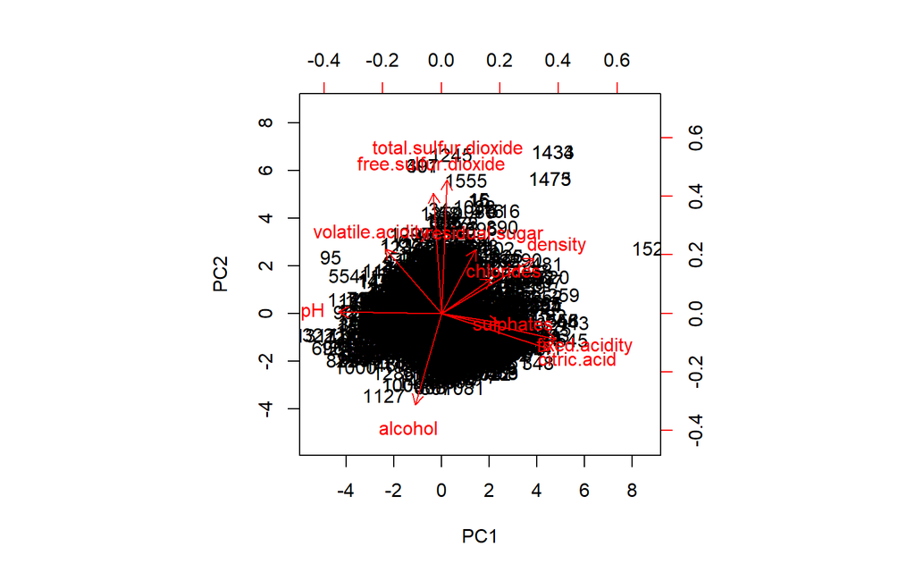

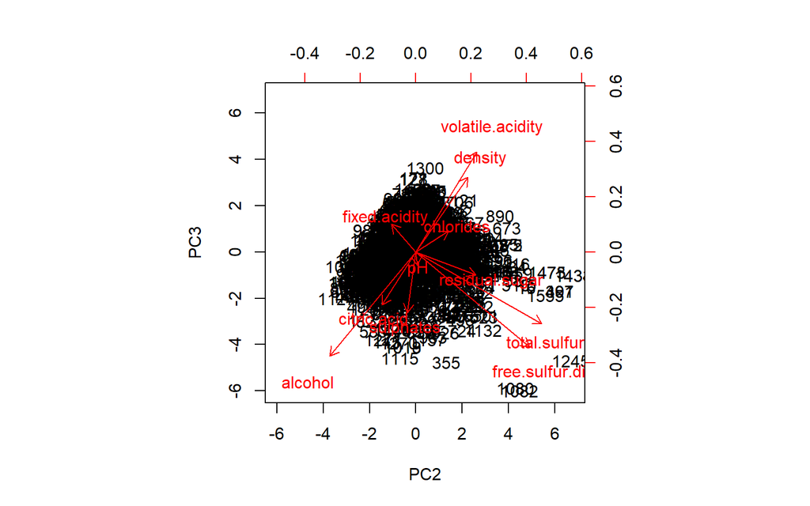

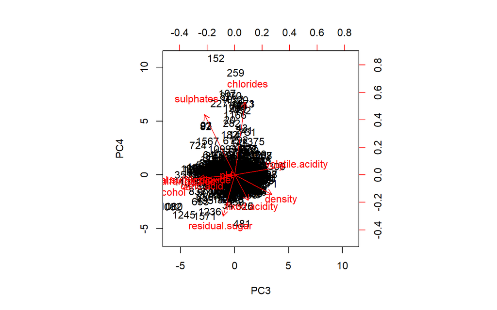

We can also plot the cumulative proportion of variance explained by the principal components:

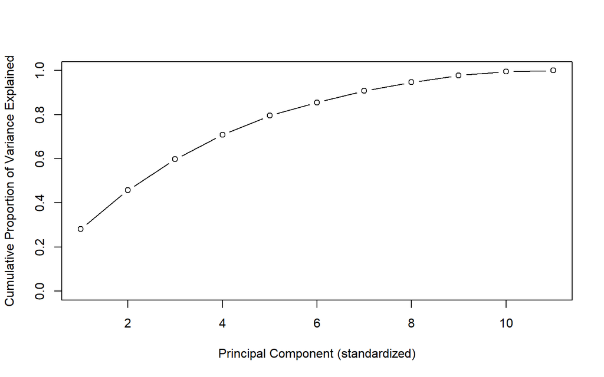

As with the entire dataset 8 principal components explain about 95% of the variance. After this, the curve starts to level off, so including these first 8 components in a model is sufficient.

### 3.3.2 White Wine PCA

Next, we subsetted the data to include only white wine. Then we eliminated all non-numeric variables because we can’t use them for PCA.

After scaling the data, we created principal components out of the variables and looked at the distribution of each one:

```
## Importance of components:
##                          PC1   PC2   PC3    PC4    PC5    PC6    PC7
## Standard deviation     1.795 1.254 1.105 1.0096 0.9870 0.9682 0.8527
## Proportion of Variance 0.293 0.143 0.111 0.0927 0.0886 0.0852 0.0661
## Cumulative Proportion  0.293 0.436 0.547 0.6396 0.7282 0.8134 0.8795
##                           PC8    PC9   PC10    PC11
## Standard deviation     0.7752 0.6438 0.5380 0.14378
## Proportion of Variance 0.0546 0.0377 0.0263 0.00188
## Cumulative Proportion  0.9341 0.9718 0.9981 1.00000
```

We also looked at how the variables make up each component:

```
##                           PC1      PC2    PC3     PC4     PC5     PC6
## fixed.acidity        -0.15693 -0.58766  0.126 -0.0290  0.2453 -0.1065
## volatile.acidity     -0.00583  0.04523 -0.591 -0.3001  0.6340  0.0989
## citric.acid          -0.14401 -0.34128  0.509 -0.1521  0.0484  0.1307
## residual.sugar       -0.42742  0.00762 -0.212  0.2721  0.0142 -0.2940
## chlorides            -0.21237 -0.00873 -0.108 -0.6946 -0.3464  0.4083
## free.sulfur.dioxide  -0.30030  0.29335  0.275  0.2979  0.2058  0.4887
## total.sulfur.dioxide -0.40663  0.24431  0.122  0.0485  0.3040  0.2688
## density              -0.51160  0.00440 -0.127  0.0251 -0.0937 -0.3260
## pH                    0.12751  0.58266  0.125 -0.0960 -0.1298 -0.1907
## sulphates            -0.04369  0.22280  0.432 -0.4613  0.3670 -0.4884
## alcohol               0.43748 -0.03332  0.106  0.1250  0.3468  0.1279
##                          PC7     PC8     PC9    PC10     PC11
## fixed.acidity         0.1999  0.5891  0.3295  0.1294 -0.17140
## volatile.acidity     -0.2724  0.0289 -0.1458  0.2250 -0.01726
## citric.acid          -0.7048 -0.1526 -0.1995  0.0397 -0.00983
## residual.sugar       -0.2126 -0.3857  0.4107 -0.0954 -0.48994
## chlorides             0.0797 -0.1002  0.3924 -0.0546 -0.02528
## free.sulfur.dioxide   0.1662 -0.0827  0.1461  0.5670  0.03091
## total.sulfur.dioxide  0.0649  0.2455 -0.1579 -0.7088 -0.03531
## density              -0.1083  0.0704  0.0877  0.0682  0.75986
## pH                   -0.4232  0.5364  0.2594  0.1107 -0.14130
## sulphates             0.3126 -0.2698 -0.0118  0.0564 -0.04173
## alcohol              -0.1307 -0.1935  0.6215 -0.2738  0.35812
```

Using biplots is another way to see how the different variables make up each component. Here are a few examples:

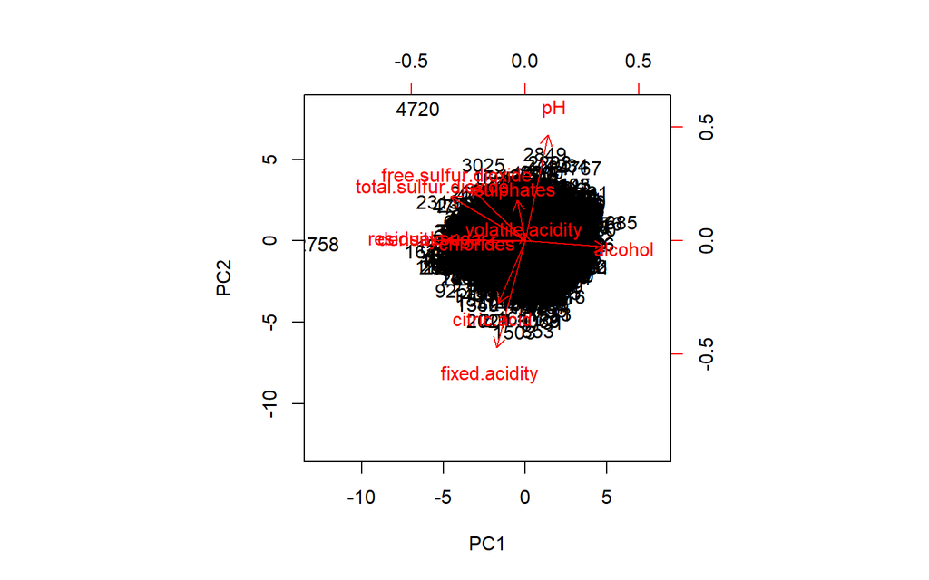

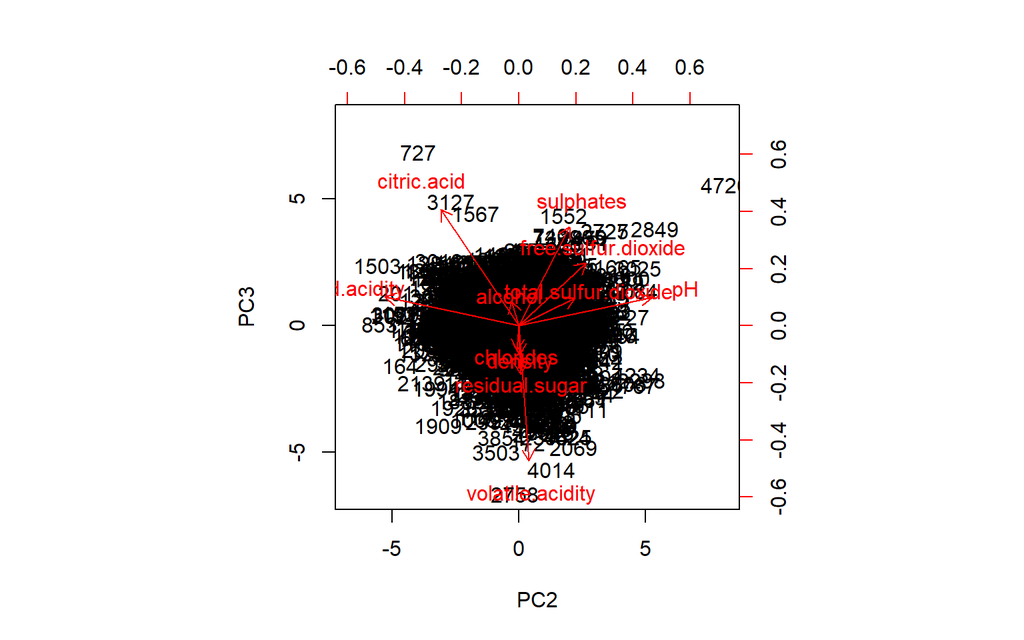

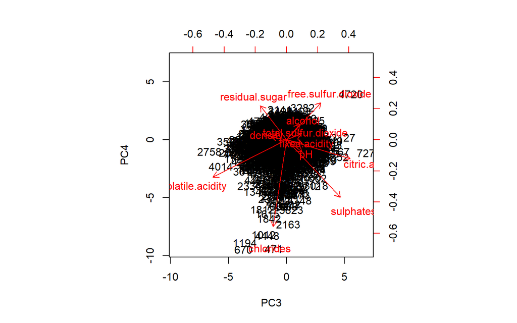

We can also plot the cumulative proportion of variance explained by the principal components:

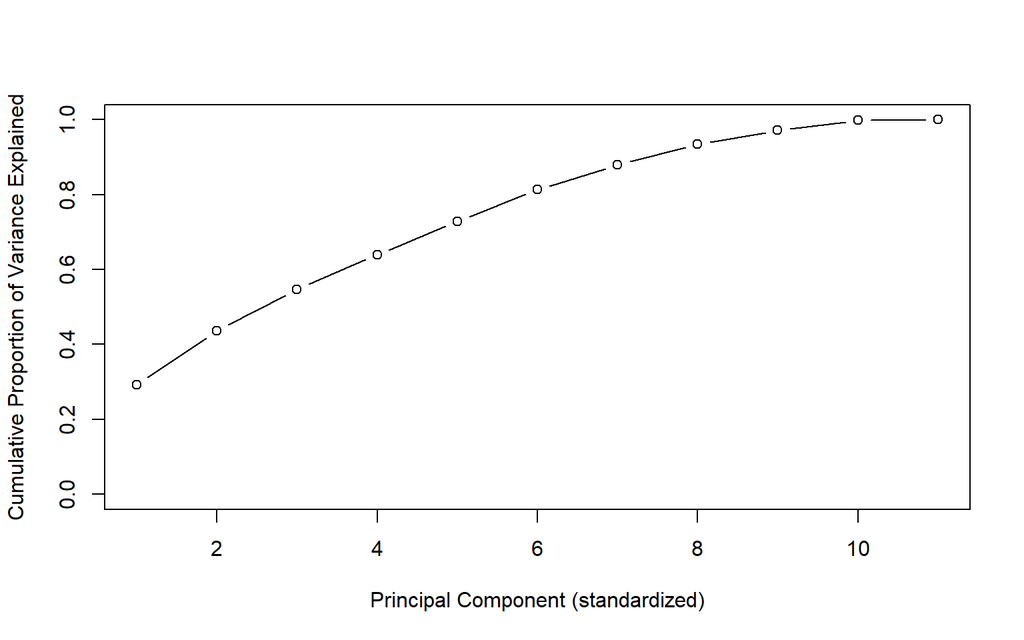

As with the entire dataset and the subset of red wine, 8 principal components is sufficient. The first 8 principal components explain about 93% of the variance.

## 3.4 PCR

### 3.4.1 Red Wine PCR

Using the 8 principal components for red wine, we created another PCR model to classify whether the red wine is high or low quality.

Table

|  | Estimate | Std. Error | z value | Pr(>\|z\|) |
| --- | --- | --- | --- | --- |
| (Intercept) | 0.2548 | 0.0611 | 4.170 | 0.0000 |
| PC1 | 0.0888 | 0.0341 | 2.606 | 0.0092 |
| PC2 | -0.7289 | 0.0506 | -14.402 | 0.0000 |
| PC3 | -0.6967 | 0.0543 | -12.838 | 0.0000 |
| PC4 | -0.0474 | 0.0536 | -0.885 | 0.3762 |
| PC5 | -0.3477 | 0.0631 | -5.506 | 0.0000 |
| PC6 | 0.1334 | 0.0758 | 1.759 | 0.0785 |
| PC7 | -0.3226 | 0.0803 | -4.017 | 0.0001 |
| PC8 | 0.1662 | 0.0949 | 1.752 | 0.0798 |

### 3.4.2 White Wine PCR

Finally, we created a PCR model to classify whether white wine is high or low quality, with the first 8 principal components.

Table

|  | Estimate | Std. Error | z value | Pr(>\|z\|) |
| --- | --- | --- | --- | --- |
| (Intercept) | 0.8198 | 0.0349 | 23.467 | 0.0000 |
| PC1 | 0.3861 | 0.0201 | 19.219 | 0.0000 |
| PC2 | 0.0857 | 0.0268 | 3.193 | 0.0014 |
| PC3 | 0.5332 | 0.0333 | 16.030 | 0.0000 |
| PC4 | 0.4544 | 0.0381 | 11.918 | 0.0000 |
| PC5 | 0.0546 | 0.0350 | 1.561 | 0.1185 |
| PC6 | -0.0523 | 0.0370 | -1.412 | 0.1580 |
| PC7 | 0.0059 | 0.0404 | 0.145 | 0.8849 |
| PC8 | -0.4868 | 0.0448 | -10.866 | 0.0000 |

## 3.5 Logistic Regression

### 3.5.1 Red Wine

We then created a full logistic regression model for red wine, using the same variables from the original data, to predict whether red wine is high or low quality:

Table

|  | Estimate | Std. Error | z value | Pr(>\|z\|) |
| --- | --- | --- | --- | --- |
| (Intercept) | -11.2294 | 84.5757 | -0.1328 | 0.8944 |
| fixed.acidity | 0.1177 | 0.0991 | 1.1881 | 0.2348 |
| volatile.acidity | -3.1794 | 0.4944 | -6.4312 | 0.0000 |
| citric.acid | -1.3578 | 0.5671 | -2.3943 | 0.0167 |
| residual.sugar | 0.0144 | 0.0596 | 0.2416 | 0.8091 |
| chlorides | -3.6697 | 1.5672 | -2.3416 | 0.0192 |
| free.sulfur.dioxide | 0.0251 | 0.0085 | 2.9407 | 0.0033 |
| total.sulfur.dioxide | -0.0192 | 0.0033 | -5.8566 | 0.0000 |
| density | 3.3128 | 86.1779 | 0.0384 | 0.9693 |
| pH | -0.3779 | 0.7232 | -0.5226 | 0.6013 |
| sulphates | 2.8856 | 0.4554 | 6.3367 | 0.0000 |
| alcohol | 0.8940 | 0.1061 | 8.4287 | 0.0000 |
| prob | 1.4581 | 0.8120 | 1.7958 | 0.0725 |

The results of this logistic regression model allow us to understand which factors improve the quality of red wine, categorized as either good or bad. We now have a fewer number of statistically significant features, which implies not all chemical composition factors are important for distinguishing between good and bad red wine. Overall, it seems free sulfur dioxide, suplphates and alcohol levels all increase the log likelihood of the red wine being categorized as ‘good’. On the other hand, features such as volatile acidity, citric acid, chlorides and total sulfur dioxide all decrease the log likelihood of red wine being classified as good, thereby increasing the likelihood of it being bad.

```
##             Predicted bad Predicted good Total
## Actual bad            545            197   742
## Actual good           225            626   851
## Total                 770            823  1593
```

```
##             Predicted bad Predicted good Total
## Actual bad            545            197   742
## Actual good           202            649   851
## Total                 747            846  1593
```

We can also look at other model evaluation metrics to determine how good this model is. First, we plot the AUC.

```
## Area under the curve: 0.823
```

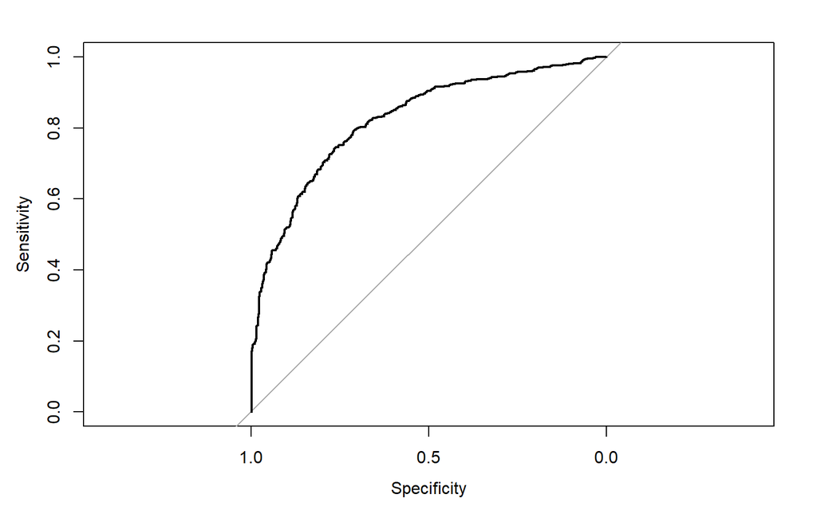

The AUC comes out to be 0.823, which is just above the 0.8 threshold. We can therefore classify this model as good. It is important to note that this AUC value is much lower than the earlier logistic regression classifying wine type, indicating this model is not as good.  
We also determine the McFadden value for this model.

```
## 'log Lik.' 0.251 (df=13)
```

This comes out to be 0.251, which means our explanatory variables explain about 25.1% of the variation in quality of red wine. This is quite low compared to our earlier model for classifying wine types. So it appears this logistic regression model may not be a good fit.

### 3.5.2 White Wine

Next, we created a full logistic regression model for the white wine, using the same variables from the original data, to predict whether white wine is high or low quality:

Table

|  | Estimate | Std. Error | z value | Pr(>\|z\|) |
| --- | --- | --- | --- | --- |
| (Intercept) | 243.3910 | 74.8233 | 3.253 | 0.0011 |
| fixed.acidity | 0.0339 | 0.0728 | 0.466 | 0.6413 |
| volatile.acidity | -6.5198 | 0.4242 | -15.371 | 0.0000 |
| citric.acid | 0.0719 | 0.3045 | 0.236 | 0.8135 |
| residual.sugar | 0.1668 | 0.0284 | 5.870 | 0.0000 |
| chlorides | 1.0030 | 1.7100 | 0.587 | 0.5575 |
| free.sulfur.dioxide | 0.0096 | 0.0028 | 3.408 | 0.0007 |
| total.sulfur.dioxide | -0.0015 | 0.0013 | -1.150 | 0.2502 |
| density | -256.3484 | 75.4943 | -3.396 | 0.0007 |
| pH | 1.0243 | 0.3647 | 2.808 | 0.0050 |
| sulphates | 1.8434 | 0.3616 | 5.098 | 0.0000 |
| alcohol | 0.7664 | 0.0973 | 7.881 | 0.0000 |
| prob | 0.4305 | 0.9455 | 0.455 | 0.6489 |

The results of this model indicate which features are important for classiying white wine as ‘good’. Residual sugar, free sulfur dioxide, pH, sulphates and alcohol all increase the log likelihood of white wine being ‘good’. On the other hand, volatile acidity and density both decrease the log likelihood of white wine being good, thereby increasing the likelihood of it being bad.

We compared the PCR model with the full logistic regression model for white wine. The AIC for the full model is again lower than for the PCR model (4920.5 vs. 5302), indicating a better fit. In addition, using the confusion matrices below, we calculated the accuracy of each model:

```
##             Predicted bad Predicted good Total
## Actual bad            632            998  1630
## Actual good           353           2887  3240
## Total                 985           3885  4870
```

```
##             Predicted bad Predicted good Total
## Actual bad            809            821  1630
## Actual good           385           2855  3240
## Total                1194           3676  4870
```

The accuracy of the PCR model is 0.723, while the accuracy of the full logistic regression model is slightly higher, at 0.752. This reinforces our finding that the full model is a better fit for white wine.

Once again, we run some additional model evaluation metrics to assess the goodness of fit for our logistic regression model.

```
## Area under the curve: 0.802
```

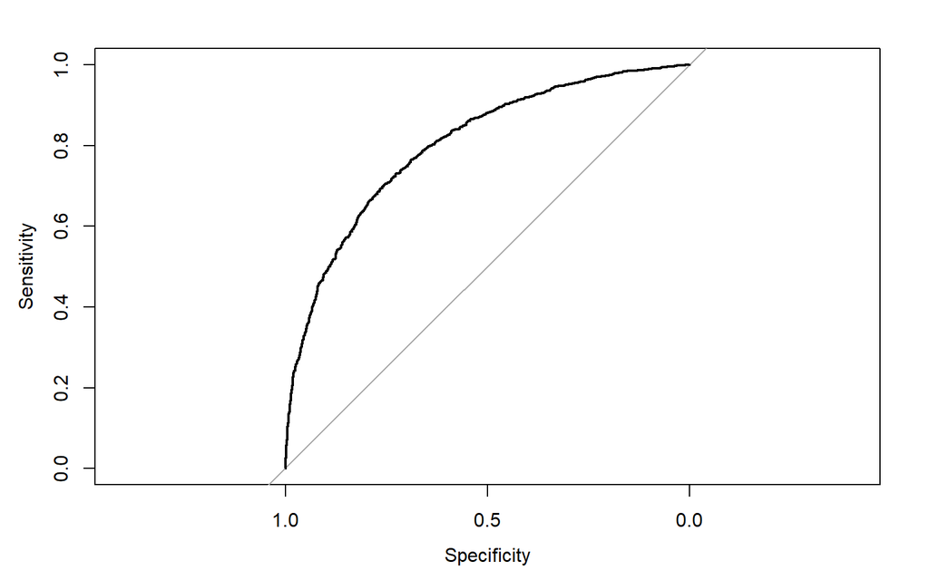

The AOC for this model is 0.802, which again is very close to the 0.8 threshold. We can conclude this model appears to be a good fit but not as good as the previous model for classifying wine type.

```
## 'log Lik.' 0.212 (df=13)
```

The McFadden value for this model comes out to be 0.212, which means the explanatory variables explain about 21.2% of the variation in quality of white wine. Again, this value is quite low so this may not be a good model.

## 3.6 KNN

### 3.6.1 Red Wine

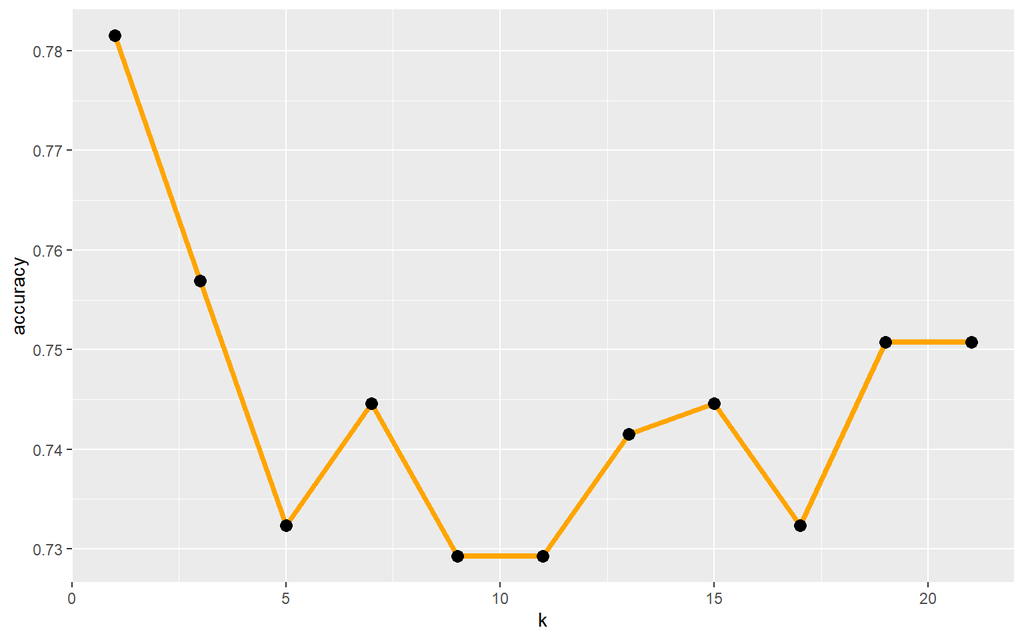

```
##
##
##    Cell Contents
## |-------------------------|
## |                       N |
## |           N / Row Total |
## |           N / Col Total |
## |         N / Table Total |
## |-------------------------|
##
##
## Total Observations in Table:  325
##
##
##                    | REDwine_pred
## redwine.testLabels |       bad |      good | Row Total |
## -------------------|-----------|-----------|-----------|
##                bad |        98 |        39 |       137 |
##                    |     0.715 |     0.285 |     0.422 |
##                    |     0.700 |     0.211 |           |
##                    |     0.302 |     0.120 |           |
## -------------------|-----------|-----------|-----------|
##               good |        42 |       146 |       188 |
##                    |     0.223 |     0.777 |     0.578 |
##                    |     0.300 |     0.789 |           |
##                    |     0.129 |     0.449 |           |
## -------------------|-----------|-----------|-----------|
##       Column Total |       140 |       185 |       325 |
##                    |     0.431 |     0.569 |           |
## -------------------|-----------|-----------|-----------|
##
##
```

```
## Confusion Matrix and Statistics
##
##                   REDwine_pred
## redwine.testLabels bad good
##               bad   98   39
##               good  42  146
##
##                Accuracy : 0.751
##                  95% CI : (0.7, 0.797)
##     No Information Rate : 0.569
##     P-Value [Acc > NIR] : 7.41e-12
##
##                   Kappa : 0.49
##
##  Mcnemar's Test P-Value : 0.824
##
##             Sensitivity : 0.700
##             Specificity : 0.789
##          Pos Pred Value : 0.715
##          Neg Pred Value : 0.777
##              Prevalence : 0.431
##          Detection Rate : 0.302
##    Detection Prevalence : 0.422
##       Balanced Accuracy : 0.745
##
##        'Positive' Class : bad
##
```

Now, we run KNN same in white wine group and let’s see how the result comes out:

### 3.6.2 White Wine

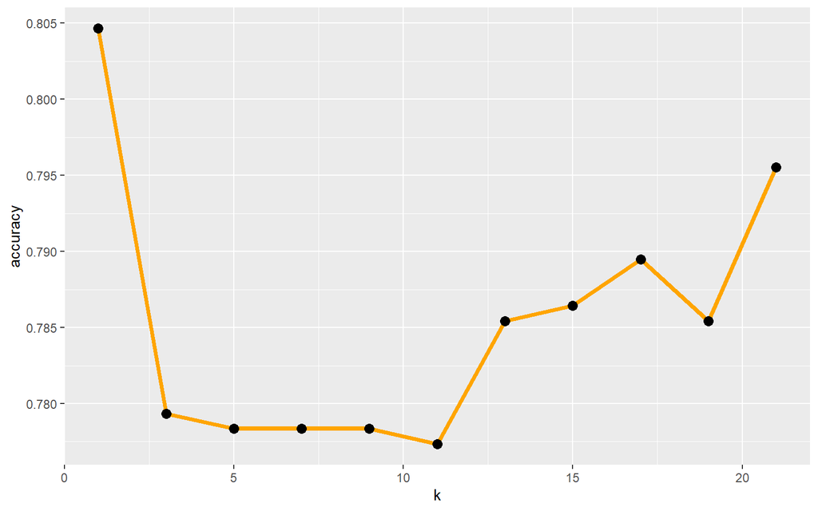

```
##
##
##    Cell Contents
## |-------------------------|
## |                       N |
## |           N / Row Total |
## |           N / Col Total |
## |         N / Table Total |
## |-------------------------|
##
##
## Total Observations in Table:  988
##
##
##                      | WHITEwine_pred
## whitewine.testLabels |       bad |      good | Row Total |
## ---------------------|-----------|-----------|-----------|
##                  bad |       198 |       122 |       320 |
##                      |     0.619 |     0.381 |     0.324 |
##                      |     0.712 |     0.172 |           |
##                      |     0.200 |     0.123 |           |
## ---------------------|-----------|-----------|-----------|
##                 good |        80 |       588 |       668 |
##                      |     0.120 |     0.880 |     0.676 |
##                      |     0.288 |     0.828 |           |
##                      |     0.081 |     0.595 |           |
## ---------------------|-----------|-----------|-----------|
##         Column Total |       278 |       710 |       988 |
##                      |     0.281 |     0.719 |           |
## ---------------------|-----------|-----------|-----------|
##
##
```

```
## Confusion Matrix and Statistics
##
##                     WHITEwine_pred
## whitewine.testLabels bad good
##                 bad  198  122
##                 good  80  588
##
##                Accuracy : 0.796
##                  95% CI : (0.769, 0.82)
##     No Information Rate : 0.719
##     P-Value [Acc > NIR] : 1.8e-08
##
##                   Kappa : 0.517
##
##  Mcnemar's Test P-Value : 0.00392
##
##             Sensitivity : 0.712
##             Specificity : 0.828
##          Pos Pred Value : 0.619
##          Neg Pred Value : 0.880
##              Prevalence : 0.281
##          Detection Rate : 0.200
##    Detection Prevalence : 0.324
##       Balanced Accuracy : 0.770
##
##        'Positive' Class : bad
##
```

## 3.7 Decision Trees

### 3.7.1 Red Wine

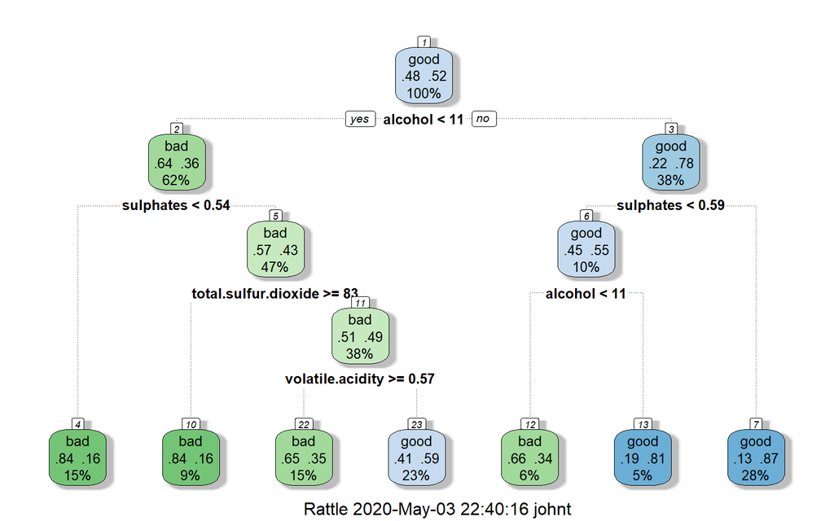

**Pruning the trees**

Classification Trees summary with varying MaxDepth

| Depth | Accuracy | Sensitivity | Specificity | Pos.Pred.Value | Neg.Pred.Value | Precision | Recall | F1 | Prevalence | Detection.Rate | Detection.Prevalence | Balanced.Accuracy |
| --- | --- | --- | --- | --- | --- | --- | --- | --- | --- | --- | --- | --- |
| 5 | 0.757 | 0.704 | 0.805 | 0.768 | 0.749 | 0.768 | 0.704 | 0.735 | 0.477 | 0.336 | 0.438 | 0.755 |
| 6 | 0.772 | 0.874 | 0.679 | 0.713 | 0.856 | 0.713 | 0.874 | 0.785 | 0.477 | 0.417 | 0.585 | 0.777 |
| 7 | 0.785 | 0.823 | 0.751 | 0.751 | 0.823 | 0.751 | 0.823 | 0.785 | 0.477 | 0.393 | 0.523 | 0.787 |
| 8 | 0.785 | 0.823 | 0.751 | 0.751 | 0.823 | 0.751 | 0.823 | 0.785 | 0.477 | 0.393 | 0.523 | 0.787 |
| 9 | 0.785 | 0.823 | 0.751 | 0.751 | 0.823 | 0.751 | 0.823 | 0.785 | 0.477 | 0.393 | 0.523 | 0.787 |

We can oberve that accuracy saturates once the max depth reached 7. Hence, we can set max-depth = 7 for better performance.

```
##
##
##    Cell Contents
## |-------------------------|
## |                       N |
## |           N / Row Total |
## |           N / Col Total |
## |         N / Table Total |
## |-------------------------|
##
##
## Total Observations in Table:  325
##
##
##                                    | predDTRed
## wine_data_step2_red_test$quality_6 |       bad |      good | Row Total |
## -----------------------------------|-----------|-----------|-----------|
##                                bad |       105 |        32 |       137 |
##                                    |     0.766 |     0.234 |     0.422 |
##                                    |     0.673 |     0.189 |           |
##                                    |     0.323 |     0.098 |           |
## -----------------------------------|-----------|-----------|-----------|
##                               good |        51 |       137 |       188 |
##                                    |     0.271 |     0.729 |     0.578 |
##                                    |     0.327 |     0.811 |           |
##                                    |     0.157 |     0.422 |           |
## -----------------------------------|-----------|-----------|-----------|
##                       Column Total |       156 |       169 |       325 |
##                                    |     0.480 |     0.520 |           |
## -----------------------------------|-----------|-----------|-----------|
##
##
```

Decision Trees Results

| Accuracy | Sensitivity | Specificity | Pos.Pred.Value | Neg.Pred.Value | Precision | Recall | F1 | Prevalence | Detection.Rate | Detection.Prevalence | Balanced.Accuracy |
| --- | --- | --- | --- | --- | --- | --- | --- | --- | --- | --- | --- |
| 0.745 | 0.766 | 0.729 | 0.673 | 0.811 | 0.673 | 0.766 | 0.717 | 0.421 | 0.323 | 0.48 | 0.748 |

Decision trees are able to classify the red wine into Good and Bad with an accuracy of **0.745**.

### 3.7.2 White Wine

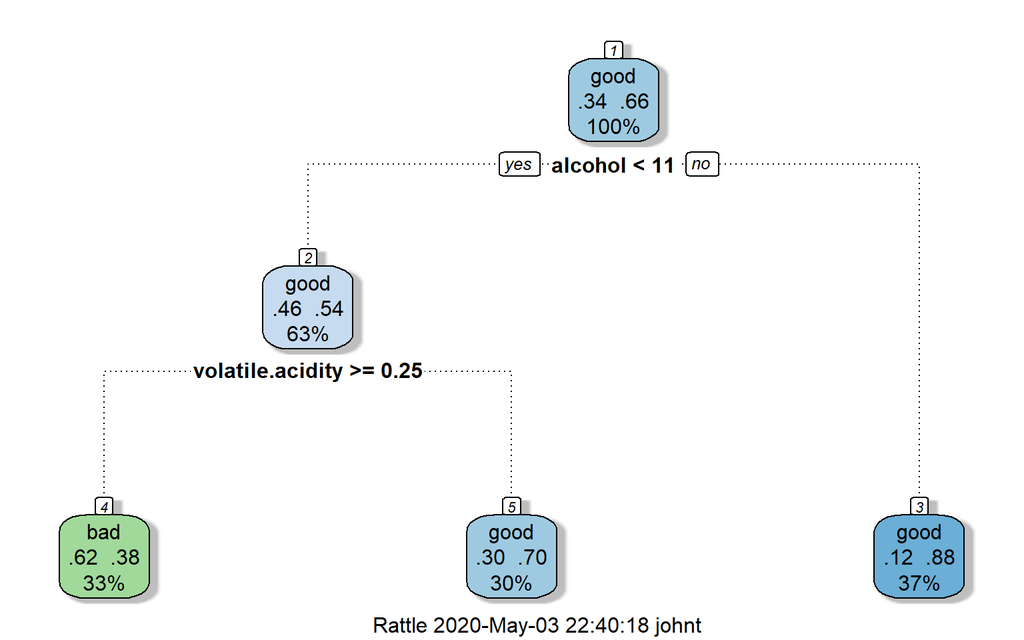

**Pruning the trees**

Classification Trees summary with varying MaxDepth

| Depth | Accuracy | Sensitivity | Specificity | Pos.Pred.Value | Neg.Pred.Value | Precision | Recall | F1 | Prevalence | Detection.Rate | Detection.Prevalence | Balanced.Accuracy |
| --- | --- | --- | --- | --- | --- | --- | --- | --- | --- | --- | --- | --- |
| 5 | 0.757 | 0.494 | 0.891 | 0.697 | 0.776 | 0.697 | 0.494 | 0.578 | 0.338 | 0.167 | 0.239 | 0.692 |
| 6 | 0.760 | 0.478 | 0.904 | 0.718 | 0.773 | 0.718 | 0.478 | 0.574 | 0.338 | 0.161 | 0.225 | 0.691 |
| 7 | 0.760 | 0.478 | 0.904 | 0.718 | 0.773 | 0.718 | 0.478 | 0.574 | 0.338 | 0.161 | 0.225 | 0.691 |
| 8 | 0.760 | 0.478 | 0.904 | 0.718 | 0.773 | 0.718 | 0.478 | 0.574 | 0.338 | 0.161 | 0.225 | 0.691 |
| 9 | 0.760 | 0.478 | 0.904 | 0.718 | 0.773 | 0.718 | 0.478 | 0.574 | 0.338 | 0.161 | 0.225 | 0.691 |

We can oberve that accuracy saturates once the max depth reached 6. Hence, we can set max-depth = 6 for better performance.

```
##
##
##    Cell Contents
## |-------------------------|
## |                       N |
## |           N / Row Total |
## |           N / Col Total |
## |         N / Table Total |
## |-------------------------|
##
##
## Total Observations in Table:  988
##
##
##                                      | predDTWhite
## wine_data_step2_white_test$quality_6 |       bad |      good | Row Total |
## -------------------------------------|-----------|-----------|-----------|
##                                  bad |       156 |       164 |       320 |
##                                      |     0.487 |     0.512 |     0.324 |
##                                      |     0.687 |     0.216 |           |
##                                      |     0.158 |     0.166 |           |
## -------------------------------------|-----------|-----------|-----------|
##                                 good |        71 |       597 |       668 |
##                                      |     0.106 |     0.894 |     0.676 |
##                                      |     0.313 |     0.784 |           |
##                                      |     0.072 |     0.604 |           |
## -------------------------------------|-----------|-----------|-----------|
##                         Column Total |       227 |       761 |       988 |
##                                      |     0.230 |     0.770 |           |
## -------------------------------------|-----------|-----------|-----------|
##
##
```

Decision Trees Results

| Accuracy | Sensitivity | Specificity | Pos.Pred.Value | Neg.Pred.Value | Precision | Recall | F1 | Prevalence | Detection.Rate | Detection.Prevalence | Balanced.Accuracy |
| --- | --- | --- | --- | --- | --- | --- | --- | --- | --- | --- | --- |
| 0.762 | 0.487 | 0.894 | 0.687 | 0.784 | 0.687 | 0.487 | 0.57 | 0.324 | 0.158 | 0.23 | 0.691 |

Decision trees are able to classify the white wine into Good and Bad with an accuracy of **0.762**.

## 3.8 Random Forest

### 3.8.1 Red Wine

**Tuning the Trees Count**

Random Forest summary with varying Trees Count

| Trees_Count | Accuracy | Sensitivity | Specificity | Pos.Pred.Value | Neg.Pred.Value | Precision | Recall | F1 | Prevalence | Detection.Rate | Detection.Prevalence | Balanced.Accuracy |
| --- | --- | --- | --- | --- | --- | --- | --- | --- | --- | --- | --- | --- |
| 250 | 0.809 | 0.808 | 0.810 | 0.795 | 0.822 | 0.795 | 0.808 | 0.802 | 0.477 | 0.386 | 0.485 | 0.809 |
| 300 | 0.808 | 0.810 | 0.805 | 0.792 | 0.823 | 0.792 | 0.810 | 0.801 | 0.477 | 0.386 | 0.488 | 0.808 |
| 350 | 0.808 | 0.805 | 0.811 | 0.796 | 0.820 | 0.796 | 0.805 | 0.800 | 0.477 | 0.384 | 0.483 | 0.808 |
| 400 | 0.808 | 0.802 | 0.814 | 0.798 | 0.818 | 0.798 | 0.802 | 0.800 | 0.477 | 0.383 | 0.479 | 0.808 |
| 450 | 0.816 | 0.818 | 0.813 | 0.800 | 0.831 | 0.800 | 0.818 | 0.809 | 0.477 | 0.390 | 0.488 | 0.816 |
| 500 | 0.809 | 0.808 | 0.810 | 0.795 | 0.822 | 0.795 | 0.808 | 0.802 | 0.477 | 0.386 | 0.485 | 0.809 |
| 550 | 0.812 | 0.812 | 0.813 | 0.798 | 0.825 | 0.798 | 0.812 | 0.805 | 0.477 | 0.387 | 0.485 | 0.812 |
| 600 | 0.809 | 0.805 | 0.813 | 0.797 | 0.820 | 0.797 | 0.805 | 0.801 | 0.477 | 0.384 | 0.482 | 0.809 |

```
##
##
##    Cell Contents
## |-------------------------|
## |                       N |
## |           N / Row Total |
## |           N / Col Total |
## |         N / Table Total |
## |-------------------------|
##
##
## Total Observations in Table:  325
##
##
##                                    | predRFRed
## wine_data_step2_red_test$quality_6 |       bad |      good | Row Total |
## -----------------------------------|-----------|-----------|-----------|
##                                bad |       107 |        30 |       137 |
##                                    |     0.781 |     0.219 |     0.422 |
##                                    |     0.811 |     0.155 |           |
##                                    |     0.329 |     0.092 |           |
## -----------------------------------|-----------|-----------|-----------|
##                               good |        25 |       163 |       188 |
##                                    |     0.133 |     0.867 |     0.578 |
##                                    |     0.189 |     0.845 |           |
##                                    |     0.077 |     0.502 |           |
## -----------------------------------|-----------|-----------|-----------|
##                       Column Total |       132 |       193 |       325 |
##                                    |     0.406 |     0.594 |           |
## -----------------------------------|-----------|-----------|-----------|
##
##
```

Random Forest Results

| Accuracy | Sensitivity | Specificity | Pos.Pred.Value | Neg.Pred.Value | Precision | Recall | F1 | Prevalence | Detection.Rate | Detection.Prevalence | Balanced.Accuracy |
| --- | --- | --- | --- | --- | --- | --- | --- | --- | --- | --- | --- |
| 0.831 | 0.781 | 0.867 | 0.811 | 0.845 | 0.811 | 0.781 | 0.795 | 0.421 | 0.329 | 0.406 | 0.824 |

### 3.8.2 White Wine

**Tuning the Trees Count**

Random Forest summary with varying Trees Count

| Trees_Count | Accuracy | Sensitivity | Specificity | Pos.Pred.Value | Neg.Pred.Value | Precision | Recall | F1 | Prevalence | Detection.Rate | Detection.Prevalence | Balanced.Accuracy |
| --- | --- | --- | --- | --- | --- | --- | --- | --- | --- | --- | --- | --- |
| 250 | 0.830 | 0.700 | 0.897 | 0.775 | 0.854 | 0.775 | 0.700 | 0.736 | 0.338 | 0.236 | 0.305 | 0.798 |
| 300 | 0.832 | 0.705 | 0.897 | 0.776 | 0.857 | 0.776 | 0.705 | 0.739 | 0.338 | 0.238 | 0.306 | 0.801 |
| 350 | 0.830 | 0.699 | 0.897 | 0.776 | 0.854 | 0.776 | 0.699 | 0.735 | 0.338 | 0.236 | 0.304 | 0.798 |
| 400 | 0.835 | 0.707 | 0.900 | 0.783 | 0.858 | 0.783 | 0.707 | 0.743 | 0.338 | 0.238 | 0.305 | 0.803 |
| 450 | 0.832 | 0.695 | 0.902 | 0.783 | 0.853 | 0.783 | 0.695 | 0.737 | 0.338 | 0.235 | 0.300 | 0.799 |
| 500 | 0.831 | 0.701 | 0.897 | 0.777 | 0.855 | 0.777 | 0.701 | 0.737 | 0.338 | 0.236 | 0.304 | 0.799 |
| 550 | 0.832 | 0.704 | 0.898 | 0.778 | 0.856 | 0.778 | 0.704 | 0.739 | 0.338 | 0.237 | 0.305 | 0.801 |
| 600 | 0.831 | 0.695 | 0.899 | 0.779 | 0.853 | 0.779 | 0.695 | 0.735 | 0.338 | 0.235 | 0.301 | 0.797 |

```
##
##
##    Cell Contents
## |-------------------------|
## |                       N |
## |           N / Row Total |
## |           N / Col Total |
## |         N / Table Total |
## |-------------------------|
##
##
## Total Observations in Table:  988
##
##
##                                      | predRFWhite
## wine_data_step2_white_test$quality_6 |       bad |      good | Row Total |
## -------------------------------------|-----------|-----------|-----------|
##                                  bad |       240 |        80 |       320 |
##                                      |     0.750 |     0.250 |     0.324 |
##                                      |     0.787 |     0.117 |           |
##                                      |     0.243 |     0.081 |           |
## -------------------------------------|-----------|-----------|-----------|
##                                 good |        65 |       603 |       668 |
##                                      |     0.097 |     0.903 |     0.676 |
##                                      |     0.213 |     0.883 |           |
##                                      |     0.066 |     0.610 |           |
## -------------------------------------|-----------|-----------|-----------|
##                         Column Total |       305 |       683 |       988 |
##                                      |     0.309 |     0.691 |           |
## -------------------------------------|-----------|-----------|-----------|
##
##
```

Random Forest Results

| Accuracy | Sensitivity | Specificity | Pos.Pred.Value | Neg.Pred.Value | Precision | Recall | F1 | Prevalence | Detection.Rate | Detection.Prevalence | Balanced.Accuracy |
| --- | --- | --- | --- | --- | --- | --- | --- | --- | --- | --- | --- |
| 0.853 | 0.75 | 0.903 | 0.787 | 0.883 | 0.787 | 0.75 | 0.768 | 0.324 | 0.243 | 0.309 | 0.826 |

Random Forest is able to classify the white wine into Good and Bad with an accuracy of **0.853**.

# 4 Conclusion

Wine Quality Classification: All Model Comparison

[output not shown]

**Random Forest** is performing the best not just in terms of wine type classification but also in the classification of wine into Good and Bad.

# 5 Bibliography

The data are from the “Wine Quality” dataset on Kaggle: https://www.kaggle.com/rajyellow46/wine-quality.